# Communicate_Findings_Exploratory

## Communicate Data Findings Project

- Introduction
- Part I - Exploratory Data Analysis
- Part II - Explanatory Analysis

### Introduction

I choose **PISA** data to analyze. PISA is a survey of students' skills and knowledge as they approach the end of compulsory education. It is not a conventional school test. Rather than examining how well students have learned the school curriculum, it looks at how well prepared they are for life beyond school.

Around 510,000 students in 65 economies took part in the PISA 2012 assessment of reading, mathematics and science representing about 28 million 15-year-olds globally. Of those economies, 44 took part in an assessment of creative problem solving and 18 in an assessment of financial literacy.

## I will investigate the answers of the next questions

Are there differences in achievement based on gender, location, wealth, or student attitudes?

Does there exist inequality in academic achievement?

## How am I going to answer these questions?

through the next two parts

#### Part I - Exploratory Data Analysis

The analysis in this part should be structured, going from simple univariate relationships up through multivariate relationships.

#### Part II - Explanatory Analysis

In this part, the plots from part one will be polished in their positions and beautification will be added.

```python
#To get started, let's import our libraries. More may be imported when needed
#import the required pakages for our analysis

import pandas as pd
import numpy as np
import matplotlib.pyplot as plt
import seaborn as sb
```

```python
#read the data
df = pd.read_csv('pisa2012.csv')
```

Let's discover the data set!

starting by its size

```python
df.shape #really huge
```

```
(485490, 636)
```

The data set is really huge. Let's discover more about its content, features, data types etc.

```python
df.columns #alot of features
```

```
Index(['Unnamed: 0', 'CNT', 'SUBNATIO', 'STRATUM', 'OECD', 'NC', 'SCHOOLID',
       'STIDSTD', 'ST01Q01', 'ST02Q01',
       ...
       'W_FSTR75', 'W_FSTR76', 'W_FSTR77', 'W_FSTR78', 'W_FSTR79', 'W_FSTR80',
       'WVARSTRR', 'VAR_UNIT', 'SENWGT_STU', 'VER_STU'],
      dtype='object', length=636)
```

```python
#familiarize myself with the data
import random
#generate 20 random numbers
randomlist = random.sample(range(0, df.shape[0]), 20)
df.loc[randomlist,'MISCED']
df['GRADE'].unique()
```

```
array([ 0., -1., -2.,  1., -3.,  2., nan,  3.])
```

After loading the variables and having a look at them, I picked some for our analysis considering all data types (categorical and numerical)

```python
variables_df = pd.read_csv('pisadict2012.csv')
#variables_df.head(20)
#pick interesting variables and give them meaningful names
short_var_dict = {'CNT':'Country','OECD':'OECD','ST01Q01':'InternationalGrade',
                  'ST04Q01':'Gender','ST03Q01':'BirthMonth','ST03Q02':'BirthYear',
                  'AGE':'AGE','ESCS':'IndexEconomicSocialCulturalStatus','MISCED':'MotherEducation',
                  'ST19Q01':'FatherJobStatus','ST88Q02':'TimeWaste','ST88Q04':'UsefulForJob',
                  'ST26Q06':'Internet','WEALTH':'Wealth','GRADE':'GRADE'}
#short_var_dict.keys()
```

```python
#subset the original df and save the new one as the original one is too large with many many features with no use for may analysis.
#from this moment on the analysis will be on the new subsetted df.
df1 = df[short_var_dict.keys()]
#change columns names for a more meaningful names
df1 = df1.rename(columns=short_var_dict)
#drop rows with missing values
df1 = df1.dropna()
df1 #this df is in a good shape for my analysis
```

|  | Country | OECD | InternationalGrade | Gender | BirthMonth | BirthYear | AGE | IndexEconomicSocialCulturalStatus | MotherEducation | FatherJobStatus | TimeWaste | UsefulForJob | Internet | Wealth | GRADE |
| --- | --- | --- | --- | --- | --- | --- | --- | --- | --- | --- | --- | --- | --- | --- | --- |
| 4743 | United Arab Emirates | Non-OECD | 10 | Male | 8 | 1996 | 15.75 | 0.65 | ISCED 5A, 6 | Working full-time <for pay> | Agree | Strongly disagree | Yes | -1.06 | 0.0 |
| 4744 | United Arab Emirates | Non-OECD | 10 | Male | 6 | 1996 | 15.92 | 0.72 | ISCED 5B | Not working, but looking for a job | Agree | Agree | Yes | 0.67 | 0.0 |
| 4745 | United Arab Emirates | Non-OECD | 10 | Male | 9 | 1996 | 15.67 | -0.09 | ISCED 5B | Working part-time <for pay> | Disagree | Strongly agree | Yes | -0.14 | 0.0 |
| 4747 | United Arab Emirates | Non-OECD | 10 | Male | 3 | 1996 | 16.17 | -0.24 | ISCED 3A, ISCED 4 | Other (e.g. home duties, retired) | Agree | Agree | Yes | -0.84 | 0.0 |
| 4748 | United Arab Emirates | Non-OECD | 9 | Male | 11 | 1996 | 15.50 | 0.25 | ISCED 5A, 6 | Not working, but looking for a job | Agree | Strongly disagree | Yes | -1.29 | -1.0 |
| ... | ... | ... | ... | ... | ... | ... | ... | ... | ... | ... | ... | ... | ... | ... | ... |
| 485483 | Vietnam | Non-OECD | 10 | Female | 1 | 1996 | 16.25 | -0.50 | ISCED 3A, ISCED 4 | Working full-time <for pay> | Strongly disagree | Strongly agree | No | -2.04 | 0.0 |
| 485484 | Vietnam | Non-OECD | 10 | Male | 8 | 1996 | 15.67 | -2.21 | None | Other (e.g. home duties, retired) | Disagree | Strongly agree | Yes | -1.06 | 0.0 |
| 485486 | Vietnam | Non-OECD | 10 | Male | 2 | 1996 | 16.17 | -1.22 | None | Other (e.g. home duties, retired) | Strongly disagree | Agree | Yes | -0.58 | 0.0 |
| 485487 | Vietnam | Non-OECD | 10 | Male | 6 | 1996 | 15.83 | -1.92 | ISCED 1 | Working full-time <for pay> | Disagree | Disagree | No | -2.04 | 0.0 |
| 485488 | Vietnam | Non-OECD | 10 | Male | 6 | 1996 | 15.83 | -0.71 | ISCED 2 | Other (e.g. home duties, retired) | Strongly disagree | Agree | Yes | -1.53 | 0.0 |

278698 rows × 15 columns

```python
df1.describe()
```

|  | InternationalGrade | BirthMonth | BirthYear | AGE | IndexEconomicSocialCulturalStatus | Wealth | GRADE |
| --- | --- | --- | --- | --- | --- | --- | --- |
| count | 278698.000000 | 278698.000000 | 278698.000000 | 278698.000000 | 278698.000000 | 278698.000000 | 278698.000000 |
| mean | 9.680740 | 6.536613 | 1996.068346 | 15.783671 | -0.203391 | -0.280945 | -0.133740 |
| std | 0.731788 | 3.419957 | 0.252340 | 0.290358 | 1.110699 | 1.195368 | 0.624277 |
| min | 7.000000 | 1.000000 | 1996.000000 | 15.250000 | -5.950000 | -6.080000 | -3.000000 |
| 25% | 9.000000 | 4.000000 | 1996.000000 | 15.580000 | -0.930000 | -0.950000 | 0.000000 |
| 50% | 10.000000 | 7.000000 | 1996.000000 | 15.750000 | -0.130000 | -0.230000 | 0.000000 |
| 75% | 10.000000 | 9.000000 | 1996.000000 | 16.000000 | 0.660000 | 0.440000 | 0.000000 |
| max | 13.000000 | 12.000000 | 1997.000000 | 16.330000 | 3.270000 | 3.250000 | 3.000000 |

```python
df1.info()
```

```
<class 'pandas.core.frame.DataFrame'>
Int64Index: 278698 entries, 4743 to 485488
Data columns (total 15 columns):
 #   Column                             Non-Null Count   Dtype
---  ------                             --------------   -----
 0   Country                            278698 non-null  object
 1   OECD                               278698 non-null  object
 2   InternationalGrade                 278698 non-null  int64
 3   Gender                             278698 non-null  object
 4   BirthMonth                         278698 non-null  int64
 5   BirthYear                          278698 non-null  int64
 6   AGE                                278698 non-null  float64
 7   IndexEconomicSocialCulturalStatus  278698 non-null  float64
 8   MotherEducation                    278698 non-null  object
 9   FatherJobStatus                    278698 non-null  object
 10  TimeWaste                          278698 non-null  object
 11  UsefulForJob                       278698 non-null  object
 12  Internet                           278698 non-null  object
 13  Wealth                             278698 non-null  float64
 14  GRADE                              278698 non-null  float64
dtypes: float64(4), int64(3), object(8)
memory usage: 34.0+ MB
```

```python
df1.Country.nunique(), df1.Country.unique();

catCols = df1.select_dtypes("object").columns

catCols= list(set(catCols))
catCols
```

```
['OECD',
 'Country',
 'UsefulForJob',
 'TimeWaste',
 'Internet',
 'MotherEducation',
 'FatherJobStatus',
 'Gender']
```

```python
df1.TimeWaste.unique()
```

```
array(['Agree', 'Disagree', 'Strongly agree', 'Strongly disagree'],
      dtype=object)
```

## Basic Exploratory Univariate Analysis

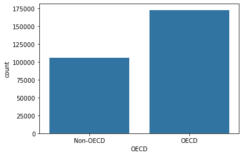

```python
#data types: qalitative and quantitative
#qalitative and nominal

# OECD stands for Organisation for Economic Co-operation and Development
base_color = sb.color_palette()[0]
sb.countplot(data=df1, x='OECD', color=base_color);
```

Non-OECD contries representation in the data is less

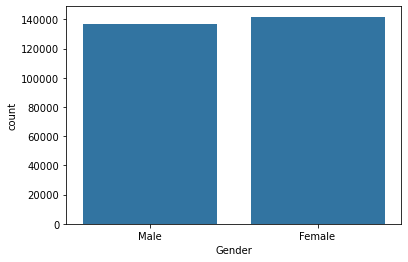

```python
sb.countplot(data=df1, x='Gender', color=base_color);
```

data represets males and females equally

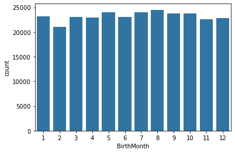

```python
sb.countplot(data=df1, x='BirthMonth', color=base_color);
```

as exprcted, BirthMonth is uniformally distributed with feb. slightly less as it is shortest.

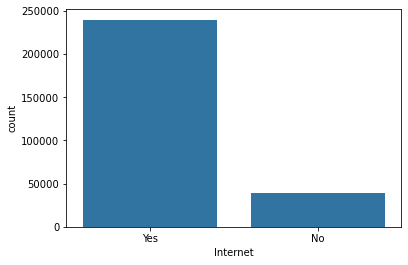

```python
sb.countplot(data=df1, x='Internet', color=base_color);
```

Most of students have internet access

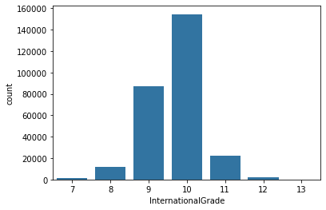

```python
#qalitative and ordinal
sb.countplot(data=df1, x='InternationalGrade', color=base_color);
plt.show()
```

The InternationalGrade is normally distributed with mode of 10.

```python
#function to plot categorical ordinal variables

def plot_percentage(df, col):
    plt.figure(figsize = [12, 5])
    ax = sb.countplot(y=col, data=df, color=base_color)
    total = len(df[col])
    for p in ax.patches:
        percentage = '{:.1f}%'.format(100 * p.get_width()/total)
        x = p.get_x() + p.get_width() + 0.02
        y = p.get_y() + p.get_height()/2
        ax.annotate(percentage, (x, y))
    return ax
#source (https://datascience.stackexchange.com/questions/48035/how-to-show-percentage-text-next-to-the-horizontal-bars-in-matplotlib)
```

ISCED 0: Early childhood education ('less than primary' for educational attainment) ISCED 1: Primary education. ISCED 2: Lower secondary education. ISCED 3: Upper secondary education. ISCED 4: Post-secondary non-tertiary education. ISCED 5: Short-cycle tertiary education.

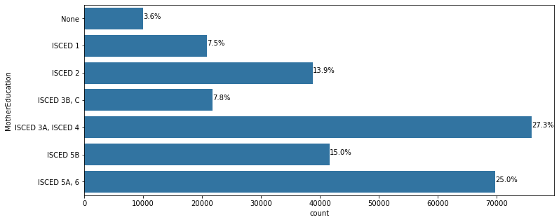

```python
plot_percentage(df1, "MotherEducation");
```

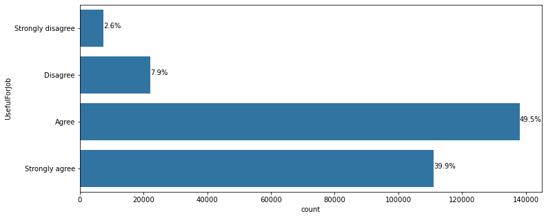

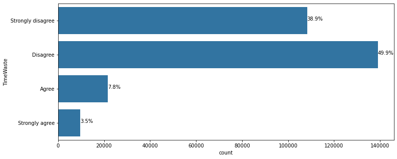

```python
plot_percentage(df1, "UsefulForJob")
plot_percentage(df1, "TimeWaste");
```

The students attitude of the usefulness of the education for a job is coherent with their denial of the education as a waste of time.

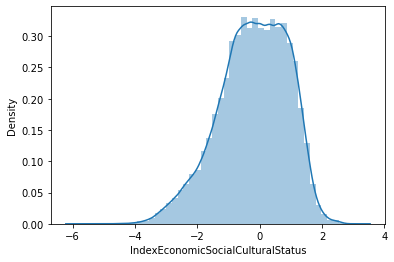

```python
#IndexEconomicSocialCulturalStatus is PISA index of economic, social and cultural status is a composite score derived from these indicators via Principal Component Analysis (PCA)
sb.distplot(df1['IndexEconomicSocialCulturalStatus']);
```

Almost normal distribution with slightly skeweness to the left and low kurtosis.

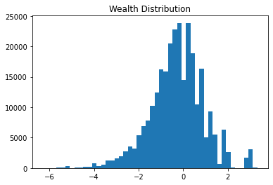

```python
bins = np.arange(df1['Wealth'].min()-.2, df1['Wealth'].max()+.2, .2)
plt.hist(data = df1, x='Wealth',bins = bins);
plt.title('Wealth Distribution')
```

Almost normal distribution with slightly skeweness to the left and low kurtosis.

## Basic Exploratory Bivariate Analysis

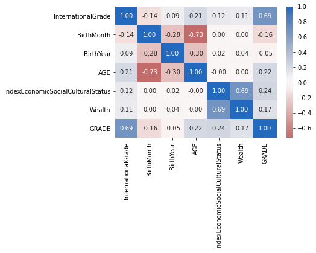

```python
sb.heatmap(df1.corr(), annot = True, fmt = '.2f', cmap = 'vlag_r', center = 0);
```

A quick investigation of the numeric variables reveal a correlation between the wealth and the index of economics social cultural status.

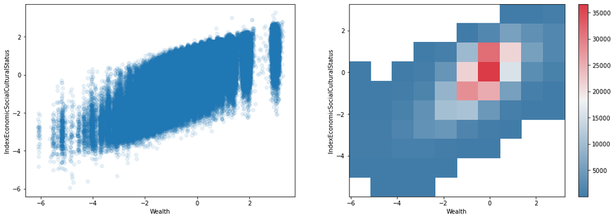

```python
# PLOT ON LEFT
plt.figure(figsize = [18, 6])
plt.subplot(1, 2, 1)
sb.regplot(data = df1, x = 'Wealth', y = 'IndexEconomicSocialCulturalStatus', x_jitter=0.04, scatter_kws={'alpha':1/10}, fit_reg=False);
plt.xlabel('Wealth')
plt.ylabel('IndexEconomicSocialCulturalStatus')

## PLOT ON RIGHT
plt.subplot(1, 2, 2)
cmap = sb.diverging_palette(240, 10, as_cmap=True)
plt.hist2d(data = df1, x = 'Wealth', y = 'IndexEconomicSocialCulturalStatus', cmin=0.5, cmap=cmap)
plt.colorbar()
plt.xlabel('Wealth')
plt.ylabel('IndexEconomicSocialCulturalStatus');

#source (https://classroom.udacity.com/nanodegrees/nd002-mena-nfp3/parts/211104e3-a5bc-4247-87b7-06bfa757806c/modules/884648ee-be0a-4bde-853f-26e97458edc8/lessons/22ff3b91-42f7-420e-b6ad-de0b29684ed0/concepts/8f54c142-468e-4e1a-abef-4c6425403a3b)
```

The overplotting of the scatter plot obscurs the distribution of the data, but this was solved by the 2D histogram. The data seems normalized to me with high concentration points around 0.

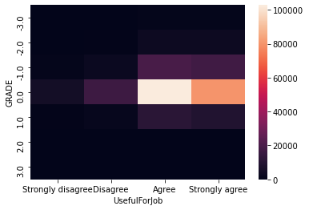

```python
ct_counts = df1.groupby(['GRADE', 'UsefulForJob']).size()
ct_counts = ct_counts.reset_index(name='count')
ct_counts = ct_counts.pivot(index = 'GRADE', columns = 'UsefulForJob', values = 'count')
sb.heatmap(ct_counts);
```

The attitude of the students towards the importance of the study for the job does not affect their grades difference from the modal grade.